# STAT 425 Final Project

Fall 2021, Ted Chen,

11/28/21

## Packages

```r
library(dplyr)
library(tidyverse)
library(ggplot2)
library(stringr)
library(readxl)
library(PerformanceAnalytics)
library(faraway)
library(earth)
library(caret)
library(pls)
set.seed(425)
```

## Exploratory Data Analysis

### Data Overview

Here we import the original file with changed column names.

We see that there is no missing values. Then, we use the `str()` and `summary()` to get a quick overview of the dataset.

```r
real <- read_excel("real_estate.xlsx")
sum(is.null(real))
```

```
## [1] 0
```

```r
str(real)
```

```
## tibble [414 × 8] (S3: tbl_df/tbl/data.frame)
##  $ No       : num [1:414] 6 7 14 20 27 39 50 105 115 135 ...
##  $ Date     : num [1:414] 2013 2013 2013 2013 2013 ...
##  $ Age      : num [1:414] 7.1 34.5 20.4 1.5 3.1 3.1 29.4 32.7 30.6 33.4 ...
##  $ Distance : num [1:414] 2175 623.5 2469.6 23.4 383.9 ...
##  $ Stores   : num [1:414] 3 7 4 7 5 6 1 6 8 6 ...
##  $ Latitude : num [1:414] 25 25 25 25 25 ...
##  $ Longitude: num [1:414] 122 122 122 122 122 ...
##  $ Price    : num [1:414] 32.1 40.3 23.8 47.7 56.2 47.7 13.2 30.5 53.3 42.2 ...
```

```r
summary(real)
```

```
##        No             Date           Age            Distance
##  Min.   :  1.0   Min.   :2013   Min.   : 0.000   Min.   :  23.38
##  1st Qu.:104.2   1st Qu.:2013   1st Qu.: 9.025   1st Qu.: 289.32
##  Median :207.5   Median :2013   Median :16.100   Median : 492.23
##  Mean   :207.5   Mean   :2013   Mean   :17.713   Mean   :1083.89
##  3rd Qu.:310.8   3rd Qu.:2013   3rd Qu.:28.150   3rd Qu.:1454.28
##  Max.   :414.0   Max.   :2014   Max.   :43.800   Max.   :6488.02
##      Stores          Latitude       Longitude         Price
##  Min.   : 0.000   Min.   :24.93   Min.   :121.5   Min.   :  7.60
##  1st Qu.: 1.000   1st Qu.:24.96   1st Qu.:121.5   1st Qu.: 27.70
##  Median : 4.000   Median :24.97   Median :121.5   Median : 38.45
##  Mean   : 4.094   Mean   :24.97   Mean   :121.5   Mean   : 37.98
##  3rd Qu.: 6.000   3rd Qu.:24.98   3rd Qu.:121.5   3rd Qu.: 46.60
##  Max.   :10.000   Max.   :25.01   Max.   :121.6   Max.   :117.50
```

From description, the unit used for unit area aren’t used in U.S., so we change it first for easier interpretation in the later step. Since the number of the house has no specific meaning, we exclude it from the prediction model.

```r
real$Price <- real$Price*0.042*1/3/3*1000
real <- real[,-c(1)]
```

## Data preprocessing

### New Variable `Trans_Year` and `Trans_Month`

We create new column `Trans_Year` and `Trans_Month` with input value derived from the transaction date column, and use that as the 7th predictor. However, we notice an inconsistency between the data description and the actual calculation.

```r
Real_Estate = real %>%
  mutate(Trans_Month = round((Date - floor(Date)), digits = 3)) %>%
  mutate(Trans_Month = ifelse(Trans_Month == 0.000, "1",
                       ifelse(Trans_Month == 0.083, "2",
                       ifelse(Trans_Month == 0.167, "3",
                       ifelse(Trans_Month == 0.250, "4",
                       ifelse(Trans_Month == 0.333, "5",
                       ifelse(Trans_Month == 0.417, "6",
                       ifelse(Trans_Month == 0.500, "7",
                       ifelse(Trans_Month == 0.583, "8",
                       ifelse(Trans_Month == 0.667, "9",
                       ifelse(Trans_Month == 0.750, "10",
                       ifelse(Trans_Month == 0.833, "11",
                       ifelse(Trans_Month == 0.917, "12",
                       Trans_Month))))))))))))) %>%
  mutate(Trans_Year = floor(Date)) %>%
  mutate(Date = NULL) %>%
  mutate(Trans_Year = factor(Trans_Year)) %>%
  mutate(Trans_Month = factor(Trans_Month)) %>%
  mutate(Stores = as.integer(Stores))
```

After creating new predictors `Trans_Year` and `Trans_Month` from predictor `Date`, we change all predictors’ types to fit the model.Below is the summary of the final data we will use for fitting the model.

```r
Real_Estate
```

| Age | Distance | Stores | Latitude | Longitude | Price | Trans_Month | Trans_Year |
| --- | --- | --- | --- | --- | --- | --- | --- |
| 7.1 | 2175.03000 | 3 | 24.96305 | 121.5125 | 149.80000 | 9 | 2012 |
| 34.5 | 623.47310 | 7 | 24.97933 | 121.5364 | 188.06667 | 9 | 2012 |
| 20.4 | 2469.64500 | 4 | 24.96108 | 121.5105 | 111.06667 | 9 | 2012 |
| 1.5 | 23.38284 | 7 | 24.96772 | 121.5410 | 222.60000 | 9 | 2012 |
| 3.1 | 383.86240 | 5 | 24.98085 | 121.5439 | 262.26667 | 9 | 2012 |
| 3.1 | 577.96150 | 6 | 24.97201 | 121.5472 | 222.60000 | 9 | 2012 |
| 29.4 | 4510.35900 | 1 | 24.94925 | 121.4954 | 61.60000 | 9 | 2012 |
| 32.7 | 392.44590 | 6 | 24.96398 | 121.5425 | 142.33333 | 9 | 2012 |
| 30.6 | 143.83830 | 8 | 24.98155 | 121.5414 | 248.73333 | 9 | 2012 |
| 33.4 | 186.96860 | 6 | 24.96604 | 121.5421 | 196.93333 | 9 | 2012 |

[output cut: 404 more lines]

### Correlation

```r
cor(Real_Estate[, -c(7, 8)])
```

```
##                   Age    Distance      Stores   Latitude   Longitude      Price
## Age        1.00000000  0.02562205  0.04959251  0.0544199 -0.04852005 -0.2105670
## Distance   0.02562205  1.00000000 -0.60251914 -0.5910666 -0.80631677 -0.6736129
## Stores     0.04959251 -0.60251914  1.00000000  0.4441433  0.44909901  0.5710049
## Latitude   0.05441990 -0.59106657  0.44414331  1.0000000  0.41292394  0.5463067
## Longitude -0.04852005 -0.80631677  0.44909901  0.4129239  1.00000000  0.5232865
## Price     -0.21056705 -0.67361286  0.57100491  0.5463067  0.52328651  1.0000000
```

```r
round(cor(Real_Estate[, -c(7, 8)]))
```

```
##           Age Distance Stores Latitude Longitude Price
## Age         1        0      0        0         0     0
## Distance    0        1     -1       -1        -1    -1
## Stores      0       -1      1        0         0     1
## Latitude    0       -1      0        1         0     1
## Longitude   0       -1      0        0         1     1
## Price       0       -1      1        1         1     1
```

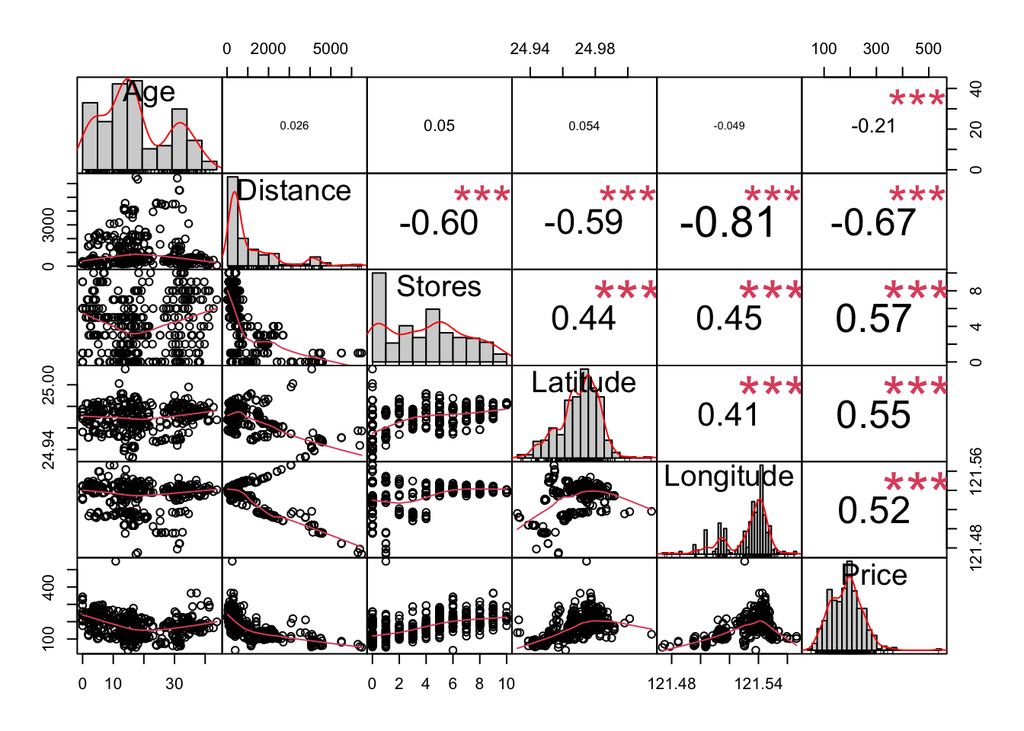

```r
chart.Correlation(Real_Estate[, -c(7, 8)], histogram = TRUE, pch = 10)
```

### Collinearity

```r
g = lm(Price ~ ., data = Real_Estate[, -c(7, 8)])
x = model.matrix(g)[,-1]
x = x - matrix(apply(x, 2, mean), 414, 5, byrow=TRUE)
x = x / matrix(apply(x, 2, sd), 414, 5, byrow=TRUE)
round(sqrt(vif(x)), dig=2)
```

```
##       Age  Distance    Stores  Latitude Longitude
##      1.01      2.07      1.27      1.26      1.71
```

The standard errors for the coefs are all very small, so we confirm that there is no collinearity issue.

### Training-Testing Dataset

We split the raw dataset to be 70% of training data and 30% of testing data.

```r
index = sort(sample(nrow(Real_Estate), nrow(Real_Estate)*0.7))
trainreal = Real_Estate[index,]
testreal = Real_Estate[-index,]
```

## Methods

### Evalutation Metrics

```r
calc_training_rmse = function(model) {
  sqrt(mean((resid(model) / (1 - hatvalues(model))) ^ 2))
}

calc_testing_rmse = function(actual, predicted) {
  sqrt(mean((actual - predicted)^2))
}

calc_testing_rsquared = function(actual, predicted) {
  rss <- sum((predicted - actual) ^ 2)
  tss <- sum((actual - mean(actual)) ^ 2)
  rsq <- 1 - rss/tss
}

result = data.frame(matrix(ncol = 5, nrow = 0))
```

### Additive Model

```r
additive_m = lm(Price ~ ., data = trainreal)
summary(additive_m)
```

```
##
## Call:
## lm(formula = Price ~ ., data = trainreal)
##
## Residuals:
##    Min     1Q Median     3Q    Max
## -74.58 -25.53  -3.41  18.06 340.32
##
## Coefficients: (1 not defined because of singularities)
##                  Estimate Std. Error t value Pr(>|t|)
## (Intercept)    -1.059e+04  3.752e+04  -0.282    0.778
## Age            -1.139e+00  2.163e-01  -5.266 2.83e-07 ***
## Distance       -2.251e-02  4.344e-03  -5.183 4.27e-07 ***
## Stores          4.628e+00  1.039e+00   4.456 1.22e-05 ***
## Latitude        1.279e+03  2.688e+02   4.757 3.19e-06 ***
## Longitude      -1.738e+02  2.974e+02  -0.585    0.559
## Trans_Month10  -6.496e+00  1.357e+01  -0.479    0.632
## Trans_Month11  -1.628e+01  1.399e+01  -1.164    0.246
## Trans_Month12  -1.517e+01  1.250e+01  -1.213    0.226
## Trans_Month2    6.053e+00  1.197e+01   0.506    0.613
## Trans_Month3   -4.772e+00  1.382e+01  -0.345    0.730
## Trans_Month4    4.404e+00  1.346e+01   0.327    0.744
## Trans_Month5    1.043e+01  1.365e+01   0.764    0.445
## Trans_Month6   -6.103e+00  1.183e+01  -0.516    0.606
## Trans_Month7    1.878e+01  1.215e+01   1.545    0.123
## Trans_Month8    2.462e+01  1.372e+01   1.794    0.074 .
## Trans_Month9   -7.506e+00  1.363e+01  -0.551    0.582
## Trans_Year2013         NA         NA      NA       NA
## ---
## Signif. codes:  0 '***' 0.001 '**' 0.01 '*' 0.05 '.' 0.1 ' ' 1
##
## Residual standard error: 41.44 on 272 degrees of freedom
## Multiple R-squared:  0.5911, Adjusted R-squared:  0.567
## F-statistic: 24.57 on 16 and 272 DF,  p-value: < 2.2e-16
```

From the table, the coefficient of predictor `Trans_Year2013` is NA, which means the variable is not linearly independent. Therefore, we remove this variable from the dataset and re-train the model.

```r
trainreal = trainreal[, -c(8)]
testreal = testreal[, -c(8)]
additive_m = lm(Price ~ ., data = trainreal)
s = summary(additive_m)
# Predict using testing data
pred = predict(additive_m, testreal)
r = c("Additive Model", round(calc_training_rmse(additive_m), 4), round(summary(additive_m)$r.squared, 4), round(calc_testing_rmse(testreal$Price, pred), 4), round(calc_testing_rsquared(testreal$Price, pred), 4))
result = rbind(result, r)
colnames(result) = c("Model", "TrainingRMSE", "Training R^2", "TestingRMSE", "Testing R^2")
result
```

| Model | TrainingRMSE | Training R^2 | TestingRMSE | Testing R^2 |
| --- | --- | --- | --- | --- |
| Additive Model | 42.8896 | 0.5911 | 42.0548 | 0.5569 |

### AIC Selection Model

```r
AIC_m = step(additive_m, direction = "both", trace = 0)
AIC_m
```

```
##
## Call:
## lm(formula = Price ~ Age + Distance + Stores + Latitude + Trans_Month,
##     data = trainreal)
##
## Coefficients:
##   (Intercept)            Age       Distance         Stores       Latitude
##    -3.218e+04     -1.137e+00     -2.062e-02      4.636e+00      1.297e+03
## Trans_Month10  Trans_Month11  Trans_Month12   Trans_Month2   Trans_Month3
##    -6.415e+00     -1.577e+01     -1.499e+01      6.595e+00     -3.941e+00
##  Trans_Month4   Trans_Month5   Trans_Month6   Trans_Month7   Trans_Month8
##     4.837e+00      1.064e+01     -5.352e+00      1.922e+01      2.433e+01
##  Trans_Month9
##    -6.772e+00
```

Using the AIC selection, we include the predictors `Age`, `Distance`, `Stores`, `Latitude`, and `Trans_Month` in our model.

```r
AIC_selection_m = lm(Price ~ Age + Distance + Stores + Latitude + Trans_Month, data = trainreal)
s = summary(AIC_selection_m)
# Predict using testing data
pred = predict(AIC_selection_m, testreal)
r = c("AIC Model", round(calc_training_rmse(AIC_selection_m), 4), round(summary(AIC_selection_m)$r.squared, 4), round(calc_testing_rmse(testreal$Price, pred), 4), round(calc_testing_rsquared(testreal$Price, pred), 4))
result = rbind(result, r)
result
```

| Model | TrainingRMSE | Training R^2 | TestingRMSE | Testing R^2 |
| --- | --- | --- | --- | --- |
| Additive Model | 42.8896 | 0.5911 | 42.0548 | 0.5569 |
| AIC Model | 42.7367 | 0.5906 | 41.9726 | 0.5586 |

### BIC Selection Model

```r
BIC_m = step(additive_m, direction = "both", k = log(length(resid(additive_m))), trace = 0)
BIC_m
```

```
##
## Call:
## lm(formula = Price ~ Age + Distance + Stores + Latitude, data = trainreal)
##
## Coefficients:
## (Intercept)          Age     Distance       Stores     Latitude
##  -3.132e+04   -1.105e+00   -2.074e-02    4.649e+00    1.263e+03
```

Using the BIC selection, we include the predictors `Age`, `Distance`, `Stores`, and `Latitude` in our model.

```r
BIC_selection_m = lm(Price ~ Age + Distance + Stores + Latitude, data = trainreal)
s = summary(BIC_selection_m)
# Predict using testing data
pred = predict(BIC_selection_m, testreal)
r = c("BIC Model", round(calc_training_rmse(BIC_selection_m), 4), round(summary(BIC_selection_m)$r.squared, 4), round(calc_testing_rmse(testreal$Price, pred), 4), round(calc_testing_rsquared(testreal$Price, pred), 4))
result = rbind(result, r)
result
```

| Model | TrainingRMSE | Training R^2 | TestingRMSE | Testing R^2 |
| --- | --- | --- | --- | --- |
| Additive Model | 42.8896 | 0.5911 | 42.0548 | 0.5569 |
| AIC Model | 42.7367 | 0.5906 | 41.9726 | 0.5586 |
| BIC Model | 42.7345 | 0.5556 | 41.0896 | 0.577 |

```r
anova(BIC_m, additive_m)
```

|  | Res.Df | RSS | Df | Sum of Sq | F | Pr(>F) |
| --- | --- | --- | --- | --- | --- | --- |
| 1 | 284 | 507636.0 | NA | NA | NA | NA |
| 2 | 272 | 467144.9 | 12 | 40491.11 | 1.964698 | 0.0275478 |

```r
shapiro.test(BIC_m$residuals)
```

```
##
##  Shapiro-Wilk normality test
##
## data:  BIC_m$residuals
## W = 0.84181, p-value < 2.2e-16
```

### BIC Normalized Model

```r
normalized_real = as.data.frame(scale(Real_Estate[, -c(7, 8)],center = TRUE, scale = TRUE))
trainreal_norm = normalized_real[index,]
testreal_norm = normalized_real[-index,]

BIC_selection_normalized_m = lm(Price ~ Age + Distance + Stores + Latitude, data = trainreal_norm)
s = summary(BIC_selection_normalized_m)
# Predict using testing data
pred = predict(BIC_selection_normalized_m, testreal_norm)
r = c("BIC Normalized Model", round(calc_training_rmse(BIC_selection_normalized_m), 4), round(summary(BIC_selection_normalized_m)$r.squared, 4), round(calc_testing_rmse(testreal_norm$Price, pred), 4), round(calc_testing_rsquared(testreal_norm$Price, pred), 4))
result = rbind(result, r)
result
```

| Model | TrainingRMSE | Training R^2 | TestingRMSE | Testing R^2 |
| --- | --- | --- | --- | --- |
| Additive Model | 42.8896 | 0.5911 | 42.0548 | 0.5569 |
| AIC Model | 42.7367 | 0.5906 | 41.9726 | 0.5586 |
| BIC Model | 42.7345 | 0.5556 | 41.0896 | 0.577 |
| BIC Normalized Model | 0.673 | 0.5556 | 0.6471 | 0.577 |

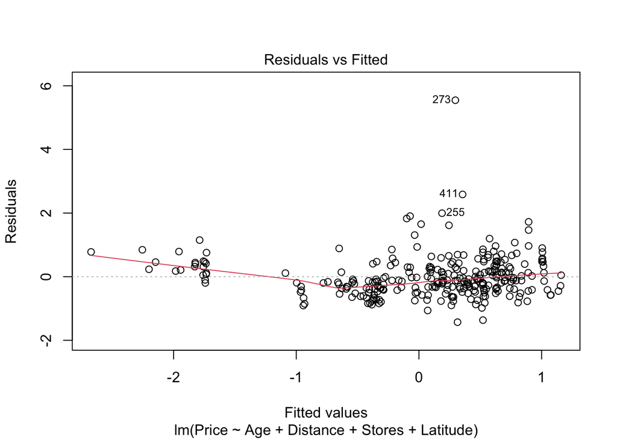

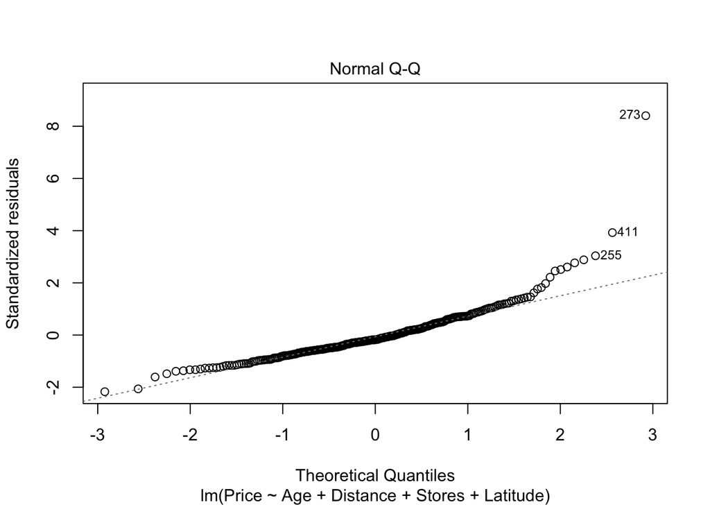

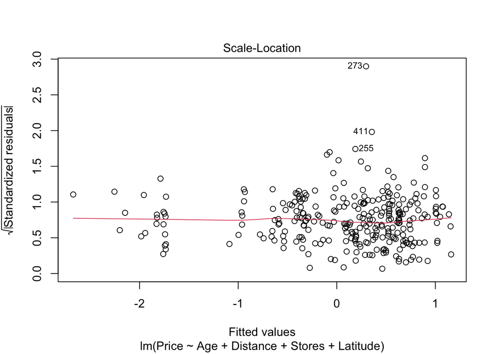

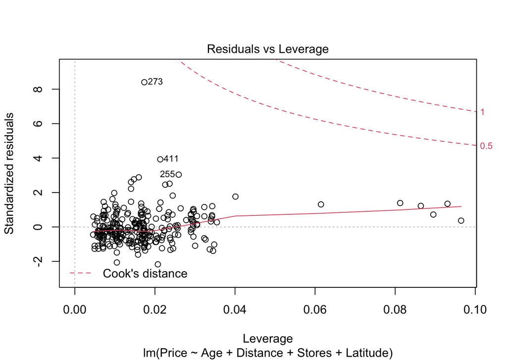

```r
plot(BIC_selection_normalized_m)
```

### Multivariate Regression Splines Model

```r
hyper_grid <- expand.grid(degree = 1:3, nprune = seq(2, 50, length.out = 10) %>%
                           floor())
```

```r
cv_mars <- train(
  x = subset(trainreal, select = -c(Price)),
  y = trainreal$Price,
  method = "earth",
  metric = "RMSE",
  trControl = trainControl(method = "cv", number = 10),
  tuneGrid = hyper_grid, )
```

```r
final = cv_mars$results %>%
  filter(nprune == cv_mars$bestTune$nprune, degree == cv_mars$bestTune$degree)
final
```

| degree | nprune | RMSE | Rsquared | MAE | RMSESD | RsquaredSD | MAESD |
| --- | --- | --- | --- | --- | --- | --- | --- |
| 1 | 7 | 35.56211 | 0.6756842 | 24.38176 | 13.79993 | 0.1614247 | 5.855047 |

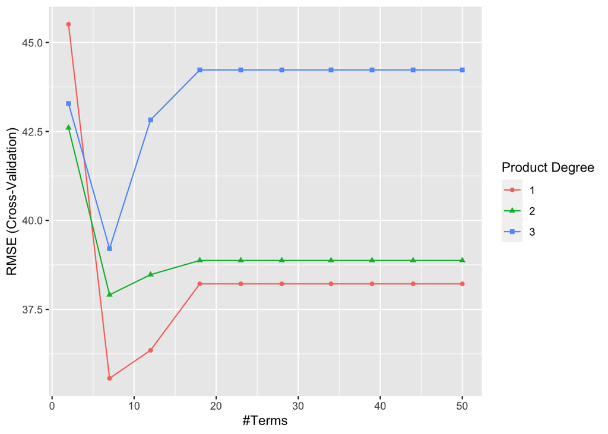

```r
r = c("Splines Model", round(final[, 3], 4), round(final[, 4], 4))
ggplot(cv_mars)
```

```r
# predict with testing data
pred = predict(cv_mars, testreal)
r = c(r, round(calc_testing_rmse(testreal$Price, pred), 4), round(calc_testing_rsquared(testreal$Price, pred), 4))
result = rbind(result, r)
result
```

| Model | TrainingRMSE | Training R^2 | TestingRMSE | Testing R^2 |
| --- | --- | --- | --- | --- |
| Additive Model | 42.8896 | 0.5911 | 42.0548 | 0.5569 |
| AIC Model | 42.7367 | 0.5906 | 41.9726 | 0.5586 |
| BIC Model | 42.7345 | 0.5556 | 41.0896 | 0.577 |
| BIC Normalized Model | 0.673 | 0.5556 | 0.6471 | 0.577 |
| Splines Model | 35.5621 | 0.6757 | 35.316 | 0.6875 |

### Principal Component Model

```r
pcr_m <- pcr(Price ~ Age + Distance + Stores + Latitude + Longitude, data = trainreal, scale=TRUE, validation="CV")
summary(pcr_m)
```

```
## Data:    X dimension: 289 5
##  Y dimension: 289 1
## Fit method: svdpc
## Number of components considered: 5
##
## VALIDATION: RMSEP
## Cross-validated using 10 random segments.
##        (Intercept)  1 comps  2 comps  3 comps  4 comps  5 comps
## CV           63.09    45.31    43.84    43.78    43.26    42.96
## adjCV        63.09    45.29    43.81    43.64    43.21    42.90
##
## TRAINING: % variance explained
##        1 comps  2 comps  3 comps  4 comps  5 comps
## X        53.80    74.13    85.94    97.13   100.00
## Price    48.89    52.62    54.24    54.60    55.57
```

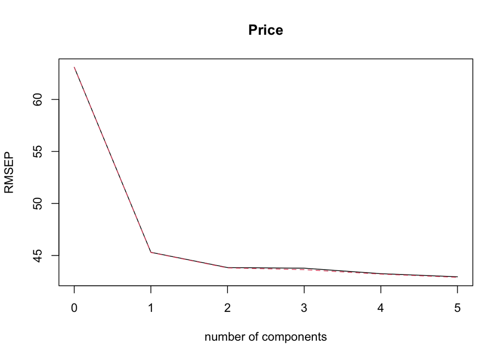

```r
validationplot(pcr_m)
validationplot(pcr_m, val.type = "RMSEP")
```

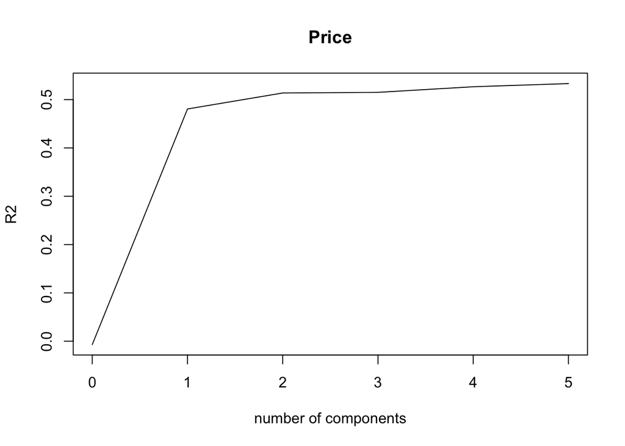

```r
validationplot(pcr_m, val.type = "R2")
```

From the cross validation result, the RMSE will be close to the smallest value and the R^2 will be close to the largest when the number of components is 4.

```r
# Predict the testing data
train_pred = predict(pcr_m, trainreal, ncomp = 4)
test_pred = predict(pcr_m, testreal, ncomp = 4)
r = c("PCR Model", round(calc_testing_rmse(trainreal$Price, train_pred), 4), round(calc_testing_rsquared(trainreal$Price, train_pred), 4), round(calc_testing_rmse(testreal$Price, test_pred), 4), round(calc_testing_rsquared(testreal$Price, test_pred), 4))
result = rbind(result, r)
result
```

| Model | TrainingRMSE | Training R^2 | TestingRMSE | Testing R^2 |
| --- | --- | --- | --- | --- |
| Additive Model | 42.8896 | 0.5911 | 42.0548 | 0.5569 |
| AIC Model | 42.7367 | 0.5906 | 41.9726 | 0.5586 |
| BIC Model | 42.7345 | 0.5556 | 41.0896 | 0.577 |
| BIC Normalized Model | 0.673 | 0.5556 | 0.6471 | 0.577 |
| Splines Model | 35.5621 | 0.6757 | 35.316 | 0.6875 |
| PCR Model | 42.3633 | 0.546 | 41.422 | 0.5701 |